# EXAMPLE PROJECT

Data Science for Biologists, Fall 2020

Stephanie J. Spielman

## Introduction

In this project, I analyze a [dataset of coffee ratings](https://github.com/rfordatascience/tidytuesday/blob/master/data/2020/2020-07-07/readme.md) from the `#tidytuesday` repository. This dataset contains information about coffees and their ratings from around the world:

```r
coffee_ratings <- readr::read_csv('https://raw.githubusercontent.com/rfordatascience/tidytuesday/master/data/2020/2020-07-07/coffee_ratings.csv')

coffee_ratings
```

```
## # A tibble: 1,339 x 43
##    total_cup_points species owner country_of_orig… farm_name lot_number mill
##               <dbl> <chr>   <chr> <chr>            <chr>     <chr>      <chr>
##  1             90.6 Arabica meta… Ethiopia         "metad p… <NA>       meta…
##  2             89.9 Arabica meta… Ethiopia         "metad p… <NA>       meta…
##  3             89.8 Arabica grou… Guatemala        "san mar… <NA>       <NA>
##  4             89   Arabica yidn… Ethiopia         "yidneka… <NA>       wole…
##  5             88.8 Arabica meta… Ethiopia         "metad p… <NA>       meta…
##  6             88.8 Arabica ji-a… Brazil            <NA>     <NA>       <NA>
##  7             88.8 Arabica hugo… Peru              <NA>     <NA>       hvc
##  8             88.7 Arabica ethi… Ethiopia         "aolme"   <NA>       c.p.…
##  9             88.4 Arabica ethi… Ethiopia         "aolme"   <NA>       c.p.…
## 10             88.2 Arabica diam… Ethiopia         "tulla c… <NA>       tull…
## # … with 1,329 more rows, and 36 more variables: ico_number <chr>,
## #   company <chr>, altitude <chr>, region <chr>, producer <chr>,
## #   number_of_bags <dbl>, bag_weight <chr>, in_country_partner <chr>,
## #   harvest_year <chr>, grading_date <chr>, owner_1 <chr>, variety <chr>,
## #   processing_method <chr>, aroma <dbl>, flavor <dbl>, aftertaste <dbl>,
## #   acidity <dbl>, body <dbl>, balance <dbl>, uniformity <dbl>,
## #   clean_cup <dbl>, sweetness <dbl>, cupper_points <dbl>, moisture <dbl>,
## #   category_one_defects <dbl>, quakers <dbl>, color <chr>,
## #   category_two_defects <dbl>, expiration <chr>, certification_body <chr>,
## #   certification_address <chr>, certification_contact <chr>,
## #   unit_of_measurement <chr>, altitude_low_meters <dbl>,
## #   altitude_high_meters <dbl>, altitude_mean_meters <dbl>
```

## Question 1

### Do Arabica or Robusta coffees have a higher mean flavor value?

#### Methods

```r
# calculate mean flavors for each species
coffee_ratings %>%
  group_by(species) %>%
  summarize(mean_flavor = mean(flavor))
```

```
## # A tibble: 2 x 2
##   species mean_flavor
##   <chr>         <dbl>
## 1 Arabica        7.52
## 2 Robusta        7.63
```

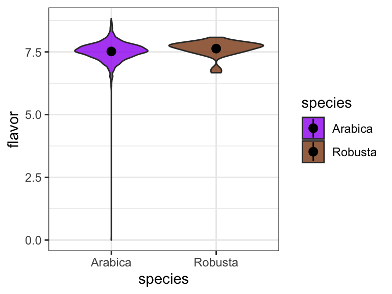

```r
# visualize flavor distributions and means per species
ggplot(coffee_ratings, aes(x = species, y = flavor, fill = species)) +
  geom_violin(alpha = 0.8) +
  scale_fill_manual(values=c("purple", "chocolate4")) +
  theme_bw() +
  stat_summary()
```

## Question 2

### To what extent does a coffee’s processing method explain its flavor rating?

#### Methods

First, I prepare the data to model.

```r
# prepare data to model
coffee_ratings %>%
  select(flavor, processing_method) %>%
  drop_na() -> coffee_ratings_model_data

# display data
coffee_ratings_model_data
```

```
## # A tibble: 1,169 x 2
##    flavor processing_method
##     <dbl> <chr>
##  1   8.83 Washed / Wet
##  2   8.67 Washed / Wet
##  3   8.58 Natural / Dry
##  4   8.5  Washed / Wet
##  5   8.42 Natural / Dry
##  6   8.5  Washed / Wet
##  7   8.58 Natural / Dry
##  8   8.67 Natural / Dry
##  9   8.42 Washed / Wet
## 10   8.67 Washed / Wet
## # … with 1,159 more rows
```

Then, I assess the assumption of equal variance across groups. The “Washed/Wet” category has a larger spread compared to the other distributions, but the difference is not severe.

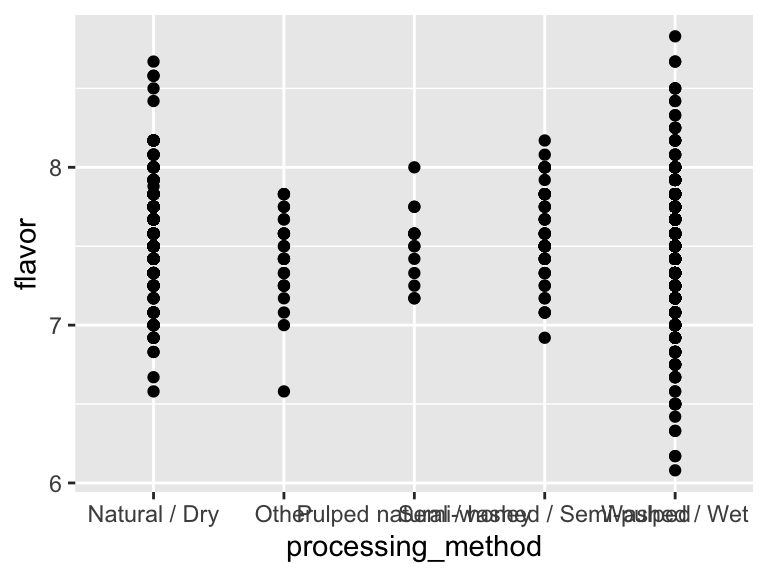

```r
# Assess assumption of roughly equal variance among processing_method groups
ggplot(coffee_ratings_model_data, aes(x = processing_method, y = flavor)) + geom_point()
```

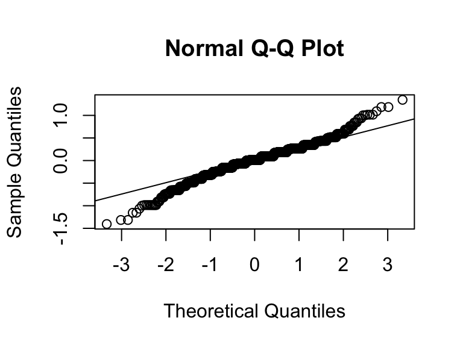

```r
# build model
fit <- lm(flavor ~ processing_method, data = coffee_ratings_model_data)

# Assess assumption of normal residuals
qqnorm(fit$residuals)
qqline(fit$residuals)
```

Now, I examine model output:

```r
summary(fit)
```

```
##
## Call:
## lm(formula = flavor ~ processing_method, data = coffee_ratings_model_data)
##
## Residuals:
##      Min       1Q   Median       3Q      Max
## -1.40553 -0.15553  0.01447  0.18447  1.34447
##
## Coefficients:
##                                             Estimate Std. Error t value
## (Intercept)                                 7.578372   0.020754 365.148
## processing_methodOther                     -0.133372   0.068593  -1.944
## processing_methodPulped natural / honey    -0.066944   0.091480  -0.732
## processing_methodSemi-washed / Semi-pulped  0.009128   0.049145   0.186
## processing_methodWashed / Wet              -0.092838   0.023814  -3.899
##                                            Pr(>|t|)
## (Intercept)                                 < 2e-16 ***
## processing_methodOther                     0.052088 .
## processing_methodPulped natural / honey    0.464450
## processing_methodSemi-washed / Semi-pulped 0.852685
## processing_methodWashed / Wet              0.000102 ***
## ---
## Signif. codes:  0 '***' 0.001 '**' 0.01 '*' 0.05 '.' 0.1 ' ' 1
##
## Residual standard error: 0.3334 on 1164 degrees of freedom
## Multiple R-squared:  0.01627,    Adjusted R-squared:  0.01289
## F-statistic: 4.814 on 4 and 1164 DF,  p-value: 0.0007458
```

Finally, I make a figure to accompany my model:

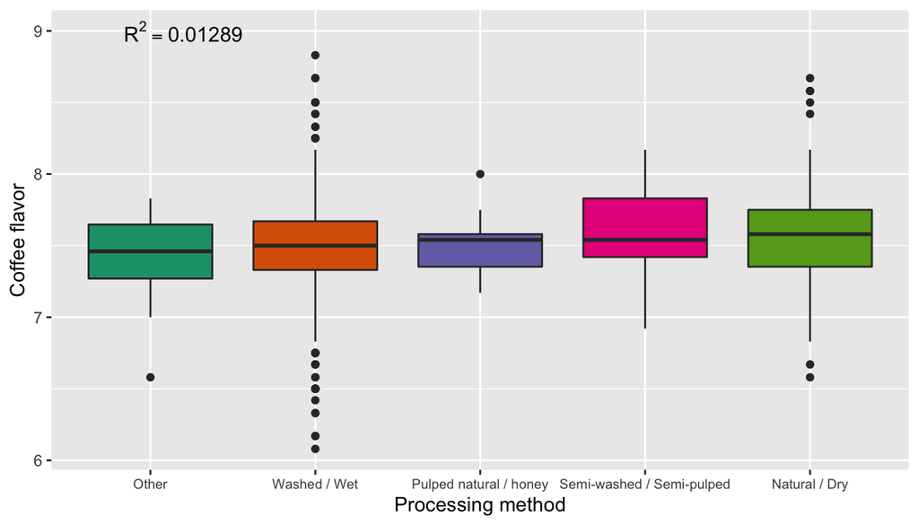

```r
ggplot(coffee_ratings_model_data, aes(x = fct_reorder(processing_method,flavor), y = flavor)) +
  # reorder x axis based on flavor
  geom_boxplot(aes(fill = fct_reorder(processing_method,flavor))) +
  scale_fill_brewer(palette = "Dark2") +
  xlab("Processing method") + ylab("Coffee flavor") +
  annotate("text", x = 1.2, y = 9, label = "R^2 == 0.01289", size=4,  parse=TRUE)  +
  theme(legend.position = "none",
        # smaller font to fit on axis
        axis.text.x = element_text(size=7.5))
```

#### Answer

This regression yielded an adjusted $R^2 = 0.01289$ with a significant P-value of 0.0007458. These results suggest that processing method, while significant, is not a strong predictor of coffee flavor, but is actually a very weak predictor. In other words, there is definitely some kind of relationship between processing method and flavor, but the relationship is extremely weak.